# Gabriel (Daeyoung) Yoo - Python, Data Analysis(EDA) and Planning

## Agenda

### 1. Business Snapshot

### 2. Women's Department Review

### 3. Sales Forecasting with Machine Learning

### This is a portfolio demonstrating how to use Python(coding & computer language) in Data Analysis, and Merchandise planning

### Below analysis is conducted for a fashion retail company with around #4000 stores. This data is altered due to privacy reason.

# Import Data

```
Frist Data Rows and Columns (55509, 25)
Second Data Total Rows and Columns (8934773, 17)
Thrid Data Total Rows and Columns (1075925, 19)
Last Data Total Rows and Columns (15732, 7)
Total Data # is 10M Rows and 25 Colums
```

### With 10M Rows and 25 columns, coding is a more effective option to conduct analysis. Similar exercise would take much more time and repetitive steps to be accomplished in Excel. Python not only provides more capacity but also the convenience of automated updates.

## Clean and Prepare Data

### Due to common errors that exist in dataset such as missing values, outliers, and various data formats that different businesses have, cleaning and preparing data is an essential step to ensure accuracy and relevancy.

## Division Level Review

### This is a quick business snapshot

#### Sell-Th at Net Ship : The range of Sell-Th is 56% - 78%. However it's importatnt to consider that avg. 30% of inventory waiting to be shipped to stores or DC.

| Department | Class | IMU | Net Ship Qty | Net Ship Qty at Retail | Net Ship Qty at Cost | Total Qty | Total Cost | Total Sales | Stock to Sales Ratio | EOH | Sell-Th at Net Ship | Gross Margin | Gross Margin $ | GMROI | Turnover | Avg Sales by Weekly | WOS |
| --- | --- | --- | --- | --- | --- | --- | --- | --- | --- | --- | --- | --- | --- | --- | --- | --- | --- |
| Acc | Flat | 0.44 | 2,708,253.0 | 7,799,768.64 | 4,333,204.8 | 1,523,914.0 | 2,438,262.4 | 4,388,056.9 | 2.29 | 1,184,339.0 | 0.56 | 0.44 | 1,949,794.5 | 7.2 | 4.0 | 72,567.33 | 16.32 |
|  | Handbag | 0.42 | 7,543,276.0 | 33,793,876.48 | 19,461,652.08 | 4,996,200.0 | 12,890,196.0 | 21,952,941.49 | 2.96 | 2,547,076.0 | 0.66 | 0.41 | 9,062,745.49 | 6.16 | 3.62 | 237,914.29 | 10.71 |
|  | Heel | 0.48 | 2,775,091.0 | 9,657,316.68 | 4,995,163.8 | 1,728,010.0 | 3,110,418.0 | 6,011,210.22 | 2.65 | 1,047,081.0 | 0.62 | 0.48 | 2,900,792.22 | 10.77 | 5.57 | 82,286.19 | 12.72 |
|  | Other Bag | 0.44 | 2,272,999.0 | 6,546,237.12 | 3,636,798.4 | 1,317,206.0 | 2,107,529.6 | 3,792,751.65 | 2.38 | 955,793.0 | 0.58 | 0.44 | 1,685,222.05 | 7.71 | 4.29 | 62,724.1 | 15.24 |
|  | Small Leather | 0.48 | 1,828,766.0 | 6,364,105.68 | 3,291,778.8 | 1,424,129.0 | 2,563,432.2 | 4,952,074.82 | 4.52 | 404,637.0 | 0.78 | 0.48 | 2,388,642.62 | 22.96 | 11.88 | 67,815.67 | 5.97 |
|  | Sneaker | 0.42 | 6,075,545.0 | 27,218,441.6 | 15,674,906.1 | 3,792,312.0 | 9,784,164.96 | 16,596,609.68 | 2.66 | 2,283,233.0 | 0.62 | 0.41 | 6,812,444.72 | 5.64 | 3.32 | 180,586.29 | 12.64 |
| Men | Basic | 0.3 | 2,747,417.0 | 9,561,011.16 | 6,731,171.65 | 2,051,826.0 | 5,026,973.7 | 7,137,763.29 | 3.95 | 695,591.0 | 0.75 | 0.3 | 2,110,789.59 | 8.67 | 6.1 | 97,706.0 | 7.12 |
|  | Coat | 0.39 | 6,620,520.0 | 29,659,929.6 | 18,007,814.4 | 4,119,192.0 | 11,204,202.24 | 18,438,804.36 | 2.65 | 2,501,328.0 | 0.62 | 0.39 | 7,234,602.12 | 5.24 | 3.18 | 196,152.0 | 12.75 |
|  | Pants | 0.39 | 8,667,096.0 | 38,828,590.08 | 23,574,501.12 | 5,654,303.0 | 15,379,704.16 | 25,307,841.42 | 2.88 | 3,012,793.0 | 0.65 | 0.39 | 9,928,137.26 | 5.73 | 3.48 | 269,252.52 | 11.19 |
|  | Short | 0.42 | 3,083,315.0 | 8,879,947.2 | 5,149,136.05 | 1,883,432.0 | 3,145,331.44 | 5,422,920.22 | 2.57 | 1,199,883.0 | 0.61 | 0.42 | 2,277,588.78 | 7.95 | 4.61 | 89,687.24 | 13.38 |
|  | Suit | 0.42 | 2,398,365.0 | 6,907,291.2 | 4,005,269.55 | 1,351,097.0 | 2,256,331.99 | 3,889,698.08 | 2.29 | 1,047,268.0 | 0.56 | 0.42 | 1,633,366.09 | 6.54 | 3.79 | 64,337.95 | 16.28 |
|  | Sweater | 0.3 | 2,023,751.0 | 7,042,653.48 | 4,958,189.95 | 1,343,953.0 | 3,292,684.85 | 4,672,411.18 | 2.98 | 679,798.0 | 0.66 | 0.3 | 1,379,726.33 | 5.8 | 4.09 | 63,997.76 | 10.62 |
| Women | Coat | 0.49 | 4,131,021.0 | 11,897,340.48 | 6,113,911.08 | 2,492,051.0 | 3,688,235.48 | 7,175,009.4 | 2.52 | 1,638,970.0 | 0.6 | 0.49 | 3,486,773.92 | 10.06 | 5.17 | 118,669.1 | 13.81 |
|  | Dress | 0.48 | 3,697,906.0 | 16,566,618.88 | 8,579,141.92 | 2,252,141.0 | 5,224,967.12 | 10,074,861.03 | 2.56 | 1,445,765.0 | 0.61 | 0.48 | 4,849,893.91 | 5.54 | 2.87 | 107,244.81 | 13.48 |
|  | Jacket | 0.48 | 3,212,062.0 | 14,390,037.76 | 7,451,983.84 | 2,004,331.0 | 4,650,047.92 | 8,968,498.58 | 2.66 | 1,207,731.0 | 0.62 | 0.48 | 4,318,450.66 | 6.67 | 3.46 | 95,444.33 | 12.65 |
|  | Jean | 0.48 | 3,286,505.0 | 14,723,542.4 | 7,624,691.6 | 1,977,836.0 | 4,588,579.52 | 8,851,273.02 | 2.51 | 1,308,669.0 | 0.6 | 0.48 | 4,262,693.5 | 6.03 | 3.12 | 94,182.67 | 13.9 |
|  | Pants | 0.48 | 3,660,903.0 | 16,400,845.44 | 8,493,294.96 | 2,080,762.0 | 4,827,367.84 | 9,307,601.46 | 2.32 | 1,580,141.0 | 0.57 | 0.48 | 4,480,233.62 | 5.01 | 2.6 | 99,083.9 | 15.95 |
|  | Short | 0.49 | 2,375,752.0 | 6,842,165.76 | 3,516,112.96 | 1,484,033.0 | 2,196,368.84 | 5,160,715.58 | 2.66 | 891,719.0 | 0.62 | 0.57 | 2,964,346.74 | 15.72 | 6.69 | 70,668.24 | 12.62 |
|  | Skirt | 0.55 | 2,610,630.0 | 9,084,992.4 | 4,098,689.1 | 1,610,721.0 | 2,528,831.97 | 5,605,684.78 | 2.61 | 999,909.0 | 0.62 | 0.55 | 3,076,852.81 | 13.72 | 6.19 | 76,701.0 | 13.04 |
|  | Sweater | 0.55 | 2,443,359.0 | 8,502,889.32 | 3,836,073.63 | 1,466,628.0 | 2,302,605.96 | 5,104,352.47 | 2.5 | 976,731.0 | 0.6 | 0.55 | 2,801,746.51 | 12.78 | 5.77 | 69,839.43 | 13.99 |

| Department | IMU | Net Ship Qty | Net Ship Qty at Retail | Net Ship Qty at Cost | Total Qty | Total Cost | Total Sales | Stock to Sales Ratio | EOH | Sell-Th at Net Ship | Gross Margin | Gross Margin $ | GMROI | Turnover | Avg Sales by Weekly | WOS |
| --- | --- | --- | --- | --- | --- | --- | --- | --- | --- | --- | --- | --- | --- | --- | --- | --- |
| Acc | 0.44 | 23,203,930.0 | 91,379,746.2 | 51,393,503.98 | 14,781,771.0 | 32,894,003.16 | 57,693,644.76 | 2.76 | 8,422,159.0 | 0.64 | 0.43 | 24,799,641.6 | 7.18 | 4.09 | 703,893.86 | 11.97 |
| Men | 0.38 | 25,540,464.0 | 100,879,422.72 | 62,426,082.72 | 16,403,803.0 | 40,305,228.38 | 64,869,438.55 | 2.8 | 9,136,661.0 | 0.64 | 0.38 | 24,564,210.17 | 6.01 | 3.74 | 781,133.48 | 11.7 |
| Women | 0.5 | 25,418,138.0 | 98,408,432.44 | 49,713,899.09 | 15,368,503.0 | 30,007,004.65 | 60,247,996.32 | 2.53 | 10,049,635.0 | 0.6 | 0.5 | 30,240,991.67 | 7.78 | 3.87 | 731,833.48 | 13.73 |

## Store Level Review

### Store Sales Distribution

#### Sales distribution is positively skewed, demonstrating more than 50% stores have sales that are lower than mean sales, 53,303.

#### Kurtosis is 3.36 Distribution has long tail and there are a few outliers with 9 stores above 200K.

#### State level sales will be presented in the following section.

```
Skewness: 1.259949
Kurtosis: 3.358098
```

[interactive chart not shown]

### There are 41 stores that have negative sales due to POS sales errors. These errors will be corrected for forecasting exercise.

```
Max sale: 304378.03000000026
Min sale: -55.740000000000016
Avg sale: 53303.7605071043

Sales bucket v/s Count of Store:
```

```
(50000, 100000]     1624
(25000, 50000]      1345
(0, 25000]           726
(100000, 150000]     290
(150000, 400000]      56
(-60, 0]              41
Name: Qty_bins, dtype: int64
```

```
(50000, 100000]    39.784419402253796
(25000, 50000]      32.94953454189123
(0, 25000]         17.785399314061735
(100000, 150000]   7.1043606075453205
(150000, 400000]   1.3718765311121999
(-60, 0]           1.0044096031357177
Name: Qty_bins, dtype: float64
```

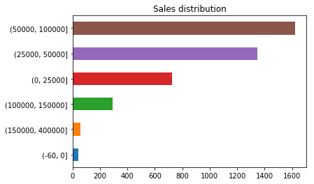

## State Level Sales

[interactive chart not shown]

| State | Store Nbr | Total Sales | Avg Sales per Store |
| --- | --- | --- | --- |
| AK | 9.0 | 276,224.0 | 30,692.0 |
| AL | 105.0 | 5,038,824.0 | 47,989.0 |
| AR | 85.0 | 2,976,960.0 | 35,023.0 |
| AZ | 89.0 | 6,033,067.0 | 67,787.0 |
| CA | 222.0 | 17,680,004.0 | 79,640.0 |
| CO | 77.0 | 2,803,521.0 | 36,409.0 |
| CT | 33.0 | 1,846,979.0 | 55,969.0 |
| DC | 3.0 | 255,695.0 | 85,232.0 |
| DE | 9.0 | 615,748.0 | 68,416.0 |
| FL | 268.0 | 19,203,738.0 | 71,656.0 |
| GA | 161.0 | 9,534,042.0 | 59,218.0 |
| HI | 10.0 | 953,007.0 | 95,301.0 |
| IA | 60.0 | 1,980,708.0 | 33,012.0 |
| ID | 25.0 | 953,890.0 | 38,156.0 |
| IL | 157.0 | 6,513,239.0 | 41,486.0 |
| IN | 103.0 | 4,856,911.0 | 47,154.0 |
| KS | 60.0 | 2,087,119.0 | 34,785.0 |
| KY | 88.0 | 4,197,930.0 | 47,704.0 |
| LA | 99.0 | 6,044,679.0 | 61,057.0 |
| MA | 49.0 | 2,616,980.0 | 53,408.0 |
| MD | 48.0 | 3,402,570.0 | 70,887.0 |
| ME | 22.0 | 553,676.0 | 25,167.0 |
| MI | 94.0 | 4,006,891.0 | 42,627.0 |
| MN | 69.0 | 2,080,978.0 | 30,159.0 |
| MO | 123.0 | 4,469,724.0 | 36,339.0 |
| MS | 73.0 | 3,663,626.0 | 50,187.0 |
| MT | 14.0 | 494,147.0 | 35,296.0 |
| NC | 160.0 | 7,996,452.0 | 49,978.0 |
| ND | 14.0 | 501,998.0 | 35,857.0 |
| NE | 36.0 | 1,410,755.0 | 39,188.0 |
| NH | 27.0 | 793,412.0 | 29,386.0 |
| NJ | 63.0 | 4,348,634.0 | 69,026.0 |
| NM | 38.0 | 1,964,619.0 | 51,701.0 |
| NV | 35.0 | 2,093,710.0 | 59,820.0 |
| NY | 98.0 | 5,336,280.0 | 54,452.0 |
| OH | 145.0 | 7,705,353.0 | 53,140.0 |
| OK | 89.0 | 3,548,166.0 | 39,867.0 |
| OR | 36.0 | 1,537,503.0 | 42,708.0 |
| PA | 137.0 | 7,472,870.0 | 54,546.0 |
| PR | 18.0 | 2,281,082.0 | 126,727.0 |
| RI | 9.0 | 493,600.0 | 54,844.0 |
| SC | 91.0 | 4,591,187.0 | 50,453.0 |
| SD | 15.0 | 516,512.0 | 34,434.0 |
| TN | 122.0 | 5,551,458.0 | 45,504.0 |
| TX | 417.0 | 28,876,739.0 | 69,249.0 |
| UT | 51.0 | 1,990,935.0 | 39,038.0 |
| VA | 120.0 | 5,600,644.0 | 46,672.0 |
| VT | 6.0 | 194,194.0 | 32,366.0 |
| WA | 63.0 | 3,048,616.0 | 48,391.0 |
| WI | 87.0 | 2,607,338.0 | 29,969.0 |
| WV | 38.0 | 1,634,119.0 | 43,003.0 |
| WY | 12.0 | 348,896.0 | 29,075.0 |

### Sales distribution Zone is decided by weather in the US, black dots represent stores.

### Most of sales comes from zone 30 to 80.

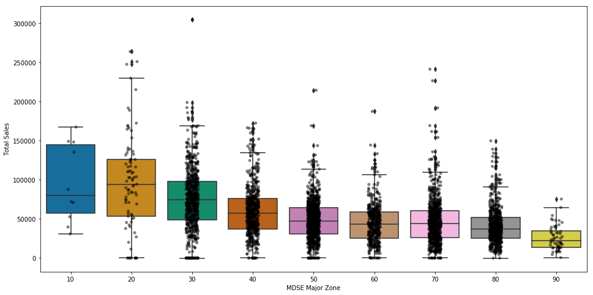

```
MDSE Major Zone
10     10
20     85
30    691
40    563
50    870
60    434
70    763
80    606
90     60
Name: Store Nbr, dtype: int64
```

### Sales distribution by Store department size. 1 to 8 means smallest to largest. from the below graph, we observe that sales are affected by store size, however, another factor to consider is actual square footage for apparel department.

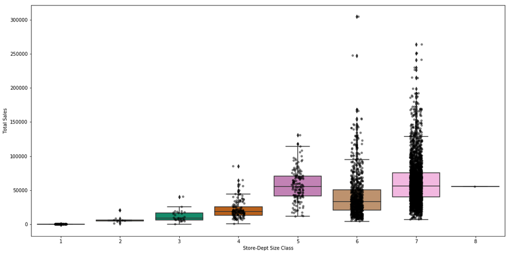

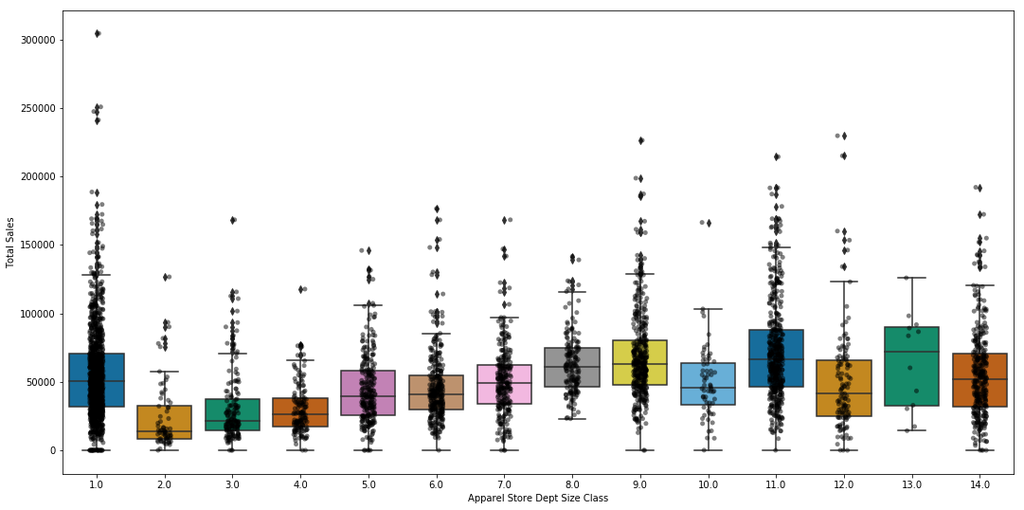

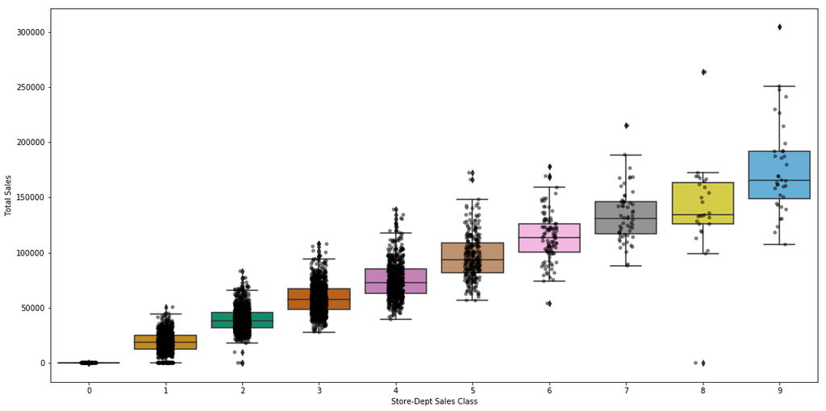

## Week-to-Week Sales Update for Women's Department

#### Women's sales by class are evenly distributed. Even though the highest number of sales for Women's department is lower than those of Men's and Accessory departments, Women's department presents the highest gross margin and GMROI compared to the rest of the two departments.

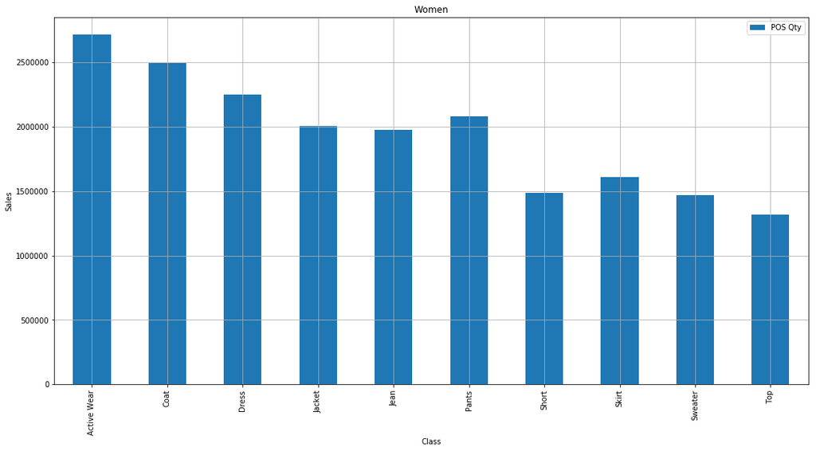

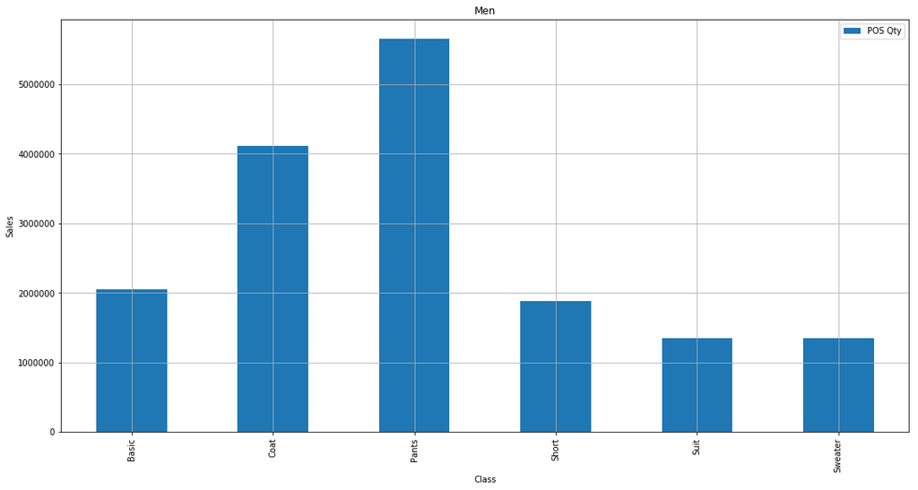

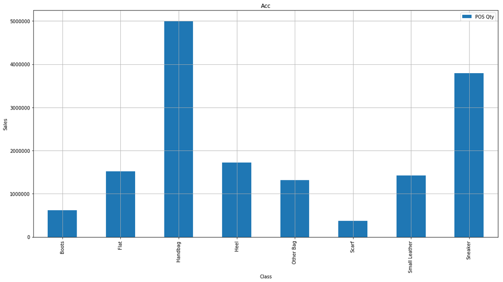

## Women's Department Report

| Year Month | 2019 | 19 Var LY | 19 Var LM | 2018 | 18 Var LY | 18 Var LM | 2017 | 17 Var LY | 17 Var LM | 2016 | 16 Var LY | 16 Var LM | 2015 | 15 Var LY | 15 Var LM | 2014 | 14 Var LM |
| --- | --- | --- | --- | --- | --- | --- | --- | --- | --- | --- | --- | --- | --- | --- | --- | --- | --- |
| Feb | 12,565,747.0 | -7.34% | nan% | 13,561,254.0 | 8.18% | nan% | 12,535,422.0 | 14.92% | nan% | 10,908,098.0 | 54.23% | nan% | 7,072,635.0 | 225.50% | nan% | 2,172,874.0 | nan% |
| Mar | 19,060,619.0 | 5.24% | 51.69% | 18,111,821.0 | 6.51% | 33.56% | 17,004,837.0 | 18.11% | 35.65% | 14,397,122.0 | 34.82% | 31.99% | 10,679,056.0 | 246.54% | 50.99% | 3,081,595.0 | 41.82% |
| Apr | 16,052,808.0 | 24.49% | -15.78% | 12,894,764.0 | -14.10% | -28.80% | 15,011,459.0 | 33.35% | -11.72% | 11,257,231.0 | 47.42% | -21.81% | 7,636,244.0 | 166.87% | -28.49% | 2,861,414.0 | -7.15% |
| May | 3,585,448.0 | -78.16% | -77.66% | 16,418,222.0 | 40.83% | 27.32% | 11,658,277.0 | 8.78% | -22.34% | 10,717,512.0 | 40.36% | -4.79% | 7,635,547.0 | 173.84% | -0.01% | 2,788,318.0 | -2.55% |
| Jun | nan | 0.00% | 0.00% | 15,463,790.0 | 20.33% | -5.81% | 12,851,494.0 | 36.34% | 10.23% | 9,425,892.0 | 18.37% | -12.05% | 7,963,403.0 | 175.25% | 4.29% | 2,893,167.0 | 3.76% |
| Jul | nan | 0.00% | 0.00% | 13,368,621.0 | 14.16% | -13.55% | 11,710,270.0 | -1.49% | -8.88% | 11,887,307.0 | 68.95% | 26.11% | 7,036,178.0 | 145.72% | -11.64% | 2,863,464.0 | -1.03% |
| Aug | nan | 0.00% | 0.00% | 13,826,526.0 | 18.27% | 3.43% | 11,690,673.0 | 22.06% | -0.17% | 9,577,879.0 | 43.67% | -19.43% | 6,666,795.0 | 98.83% | -5.25% | 3,353,044.0 | 17.10% |
| Sep | nan | 0.00% | 0.00% | 15,351,429.0 | -6.39% | 11.03% | 16,399,650.0 | 22.95% | 40.28% | 13,338,647.0 | 24.65% | 39.27% | 10,701,162.0 | 72.29% | 60.51% | 6,211,048.0 | 85.24% |
| Oct | nan | 0.00% | 0.00% | 17,046,985.0 | 20.72% | 11.04% | 14,121,416.0 | 0.02% | -13.89% | 14,118,411.0 | 25.45% | 5.85% | 11,254,404.0 | 97.62% | 5.17% | 5,695,116.0 | -8.31% |
| Nov | nan | 0.00% | 0.00% | 14,834,800.0 | 5.17% | -12.98% | 14,106,190.0 | 12.94% | -0.11% | 12,489,796.0 | 22.21% | -11.54% | 10,219,900.0 | 80.64% | -9.19% | 5,657,719.0 | -0.66% |
| Dec | nan | 0.00% | 0.00% | 23,435,270.0 | 26.78% | 57.97% | 18,484,642.0 | 11.51% | 31.04% | 16,577,092.0 | 7.03% | 32.73% | 15,488,437.0 | 125.92% | 51.55% | 6,855,611.0 | 21.17% |
| Jan | nan | 0.00% | 0.00% | 11,380,518.0 | -11.10% | -51.44% | 12,801,313.0 | 24.63% | -30.75% | 10,271,754.0 | 59.49% | -38.04% | 6,440,197.0 | 52.72% | -58.42% | 4,217,096.0 | -38.49% |

[interactive chart not shown]

| Year Week | 2014 | 2015 | 2016 | 2017 | 2018 | 2019 |
| --- | --- | --- | --- | --- | --- | --- |
| 12.0 | 696,719.0 | 1,892,443.0 | 3,109,209.0 | 3,959,447.0 | 3,080,248.0 | 4,428,141.0 |
| 13.0 | 671,509.0 | 1,746,388.0 | 2,964,460.0 | 3,133,057.0 | 3,224,027.0 | 3,929,410.0 |
| 14.0 | 730,277.0 | 2,265,680.0 | 2,812,912.0 | 3,097,503.0 | 4,333,040.0 | 3,585,448.0 |
| 15.0 | 701,620.0 | 1,915,888.0 | 2,601,493.0 | 2,708,896.0 | 4,523,751.0 | nan |
| 16.0 | 684,575.0 | 1,797,470.0 | 2,512,843.0 | 3,066,268.0 | 3,856,785.0 | nan |

[interactive chart not shown]

| Year | Sat Qty | Sat % | Sun MV 4YR | Sun Qty | Sun % | Mon MV 4YR | Mon Qty | Mon % | Tue MV 4YR | Tue Qty | ... | Wed Qty | Wed % | Thu MV 4YR | Thu Qty | Thu % | Fri MV 4YR | Fri Qty | Fri % | Sat MV 4YR | Total Qty |
| --- | --- | --- | --- | --- | --- | --- | --- | --- | --- | --- | --- | --- | --- | --- | --- | --- | --- | --- | --- | --- | --- |
| 2014 | 130,861.0 | 4.40% | -33.34% | 98,996.0 | -32.19% | -26.94% | 73,241.0 | -35.16% | 0.49% | 77,989.0 | ... | 83,019.0 | 6.06% | 4.98% | 95,364.0 | 12.95% | 21.17% | 125,105.0 | 23.77% | 15.81% | 684,575.0 |
| 2015 | 363,672.0 | 17.39% | -25.68% | 292,308.0 | -24.41% | -34.06% | 208,698.0 | -40.06% | 1.16% | 201,457.0 | ... | 209,676.0 | 3.92% | 5.65% | 221,236.0 | 5.23% | 20.78% | 300,423.0 | 26.36% | 16.21% | 1,797,470.0 |
| 2016 | 529,469.0 | 18.25% | -25.81% | 391,474.0 | -35.25% | -35.18% | 275,589.0 | -42.05% | 0.19% | 267,553.0 | ... | 289,433.0 | 7.56% | 5.65% | 326,501.0 | 11.35% | 21.79% | 432,824.0 | 24.56% | 17.00% | 2,512,843.0 |
| 2017 | 523,742.0 | -8.11% | -29.22% | 349,549.0 | -49.83% | -37.35% | 357,064.0 | 2.10% | -0.55% | 382,180.0 | ... | 417,755.0 | 8.52% | 7.99% | 469,761.0 | 11.07% | 23.47% | 566,217.0 | 17.04% | 16.06% | 3,066,268.0 |
| 2018 | 746,210.0 | 12.42% | -35.42% | 477,501.0 | -56.27% | -28.79% | 465,822.0 | -2.51% | 1.52% | 485,082.0 | ... | 492,443.0 | 1.49% | 10.15% | 536,174.0 | 8.16% | 22.93% | 653,553.0 | 17.96% | 7.98% | 3,856,785.0 |
| 2019 | 599,888.0 | 100.00% | -41.44% | 358,410.0 | -67.37% | -20.63% | 0.0 | -inf% | 0.99% | 0.0 | ... | 0.0 | nan% | 8.95% | 0.0 | nan% | 21.48% | 0.0 | nan% | 9.99% | 958,298.0 |

6 rows × 22 columns

| Week | Year | Sat Qty | Sat % | Sun MV 4YR | Sun Qty | Sun % | Mon MV 4YR | Mon Qty | Mon % | Tue MV 4YR | Tue Qty | ... | Wed Qty | Wed % | Thu MV 4YR | Thu Qty | Thu % | Fri MV 4YR | Fri Qty | Fri % | Sat MV 4YR | Total Qty |
| --- | --- | --- | --- | --- | --- | --- | --- | --- | --- | --- | --- | --- | --- | --- | --- | --- | --- | --- | --- | --- | --- | --- |
| 48.0 | 2018 | 12,671.0 | -167.54% | nan% | 18,774.0 | 32.51% | nan% | 18,850.0 | 0.40% | nan% | 0.0 | ... | 17,321.0 | 100.00% | nan% | 23,259.0 | 25.53% | nan% | 33,900.0 | 31.39% | nan% | 124,775.0 |
| 49.0 | 2018 | 39,704.0 | -93.71% | nan% | 36,846.0 | -7.76% | nan% | 35,575.0 | -3.57% | nan% | 34,191.0 | ... | 42,611.0 | 19.76% | nan% | 57,006.0 | 25.25% | nan% | 76,911.0 | 25.88% | nan% | 322,844.0 |
| 50.0 | 2018 | 94,298.0 | -21.23% | nan% | 73,980.0 | -27.46% | nan% | 65,888.0 | -12.28% | nan% | 73,456.0 | ... | 74,636.0 | 1.58% | nan% | 84,981.0 | 12.17% | nan% | 114,316.0 | 25.66% | nan% | 581,555.0 |
| 51.0 | 2018 | 135,318.0 | -6.95% | nan% | 109,064.0 | -24.07% | nan% | 80,976.0 | -34.69% | nan% | 82,588.0 | ... | 89,232.0 | 7.45% | nan% | 101,190.0 | 11.82% | nan% | 144,719.0 | 30.08% | nan% | 743,087.0 |
| 52.0 | 2018 | 150,835.0 | -1.98% | -6.70% | 106,132.0 | -42.12% | -12.53% | 86,775.0 | -22.31% | nan% | 85,240.0 | ... | 92,743.0 | 8.09% | 18.69% | 108,333.0 | 14.39% | 28.25% | 153,823.0 | 29.57% | -72.36% | 783,881.0 |
| 01.0 | 2019 | 191,367.0 | -43.62% | -25.35% | 154,317.0 | -24.01% | -18.21% | 119,640.0 | -28.98% | 1.60% | 115,037.0 | ... | 120,487.0 | 4.52% | 15.91% | 157,072.0 | 23.29% | 27.80% | 274,843.0 | 42.85% | -30.97% | 1,132,763.0 |
| 02.0 | 2019 | 340,316.0 | 3.65% | -29.42% | 260,597.0 | -30.59% | -24.56% | 212,291.0 | -22.75% | 1.61% | 224,625.0 | ... | 237,778.0 | 5.53% | 15.42% | 269,780.0 | 11.86% | 32.04% | 327,882.0 | 17.72% | -18.44% | 1,873,269.0 |
| 03.0 | 2019 | 382,631.0 | 3.86% | -30.20% | 295,492.0 | -29.49% | -27.18% | 220,505.0 | -34.01% | 0.41% | 227,171.0 | ... | 316,296.0 | 28.18% | 15.34% | 250,196.0 | -26.42% | 30.06% | 367,868.0 | 31.99% | -12.22% | 2,060,159.0 |
| 04.0 | 2019 | 436,593.0 | -26.80% | -31.55% | 324,086.0 | -34.72% | -27.01% | 243,100.0 | -33.31% | 0.66% | 214,055.0 | ... | 243,133.0 | 11.96% | 5.78% | 336,405.0 | 27.73% | 30.53% | 553,579.0 | 39.23% | -9.52% | 2,350,951.0 |
| 05.0 | 2019 | 987,875.0 | 33.48% | -29.70% | 494,375.0 | -99.82% | -29.76% | 352,516.0 | -40.24% | -2.29% | 392,978.0 | ... | 684,248.0 | 42.57% | 9.12% | 596,333.0 | -14.74% | 32.95% | 657,139.0 | 9.25% | -15.73% | 4,165,464.0 |
| 06.0 | 2019 | 720,081.0 | 30.11% | -48.65% | 556,019.0 | -29.51% | -32.58% | 366,207.0 | -51.83% | 1.29% | 356,117.0 | ... | 380,052.0 | 6.30% | -0.39% | 408,721.0 | 7.01% | 24.55% | 503,277.0 | 18.79% | 3.55% | 3,290,474.0 |
| 07.0 | 2019 | 635,476.0 | 9.97% | -48.38% | 533,630.0 | -19.09% | -39.85% | 388,773.0 | -37.26% | -0.79% | 389,269.0 | ... | 420,334.0 | 7.39% | -1.61% | 477,090.0 | 11.90% | 24.81% | 572,135.0 | 16.61% | 10.16% | 3,416,707.0 |
| 08.0 | 2019 | 661,666.0 | 14.83% | -45.78% | 549,926.0 | -20.32% | -40.66% | 397,449.0 | -38.36% | -1.49% | 387,923.0 | ... | 417,852.0 | 7.16% | 7.97% | 436,606.0 | 4.30% | 20.97% | 563,527.0 | 22.52% | 11.69% | 3,414,949.0 |
| 09.0 | 2019 | 673,361.0 | 11.34% | -42.18% | 561,187.0 | -19.99% | -41.92% | 404,218.0 | -38.83% | 1.28% | 402,794.0 | ... | 430,260.0 | 6.38% | 2.12% | 456,691.0 | 5.79% | 16.79% | 596,981.0 | 23.50% | 22.10% | 3,525,492.0 |
| 10.0 | 2019 | 701,516.0 | 17.67% | -22.22% | 543,388.0 | -29.10% | -41.57% | 417,967.0 | -30.01% | -1.38% | 393,170.0 | ... | 445,051.0 | 11.66% | 7.25% | 451,364.0 | 1.40% | 20.36% | 577,571.0 | 21.85% | 16.56% | 3,530,027.0 |
| 11.0 | 2019 | 714,616.0 | 6.45% | -22.12% | 619,988.0 | -15.26% | -36.12% | 498,375.0 | -24.40% | -2.25% | 513,955.0 | ... | 536,461.0 | 4.20% | 5.84% | 536,488.0 | 0.01% | 21.12% | 668,521.0 | 19.75% | 13.45% | 4,088,404.0 |
| 12.0 | 2019 | 779,439.0 | -15.62% | -21.17% | 631,137.0 | -23.50% | -32.90% | 466,022.0 | -35.43% | -1.52% | 496,404.0 | ... | 558,793.0 | 11.16% | 2.87% | 624,774.0 | 10.56% | 21.91% | 901,163.0 | 30.67% | 12.57% | 4,457,732.0 |
| 13.0 | 2019 | 1,032,331.0 | 40.84% | -21.96% | 556,799.0 | -85.40% | -32.17% | 411,963.0 | -35.16% | 0.62% | 423,810.0 | ... | 459,473.0 | 7.76% | 4.44% | 493,177.0 | 6.83% | 23.94% | 610,680.0 | 19.24% | 4.96% | 3,988,233.0 |
| 14.0 | 2019 | 674,083.0 | 3.12% | -38.32% | 539,710.0 | -24.90% | -31.25% | 375,801.0 | -43.62% | 1.41% | 404,196.0 | ... | 511,123.0 | 20.92% | 4.70% | 514,507.0 | 0.66% | 22.88% | 653,033.0 | 21.21% | 12.34% | 3,672,453.0 |
| 15.0 | 2019 | 710,667.0 | 24.18% | -37.27% | 568,400.0 | -25.03% | -34.65% | 430,191.0 | -32.13% | 4.74% | 423,059.0 | ... | 424,881.0 | 0.43% | 4.51% | 435,531.0 | 2.45% | 22.72% | 538,808.0 | 19.17% | 8.70% | 3,531,537.0 |
| 16.0 | 2019 | 599,888.0 | 100.00% | -39.71% | 358,410.0 | -67.37% | -36.58% | 0.0 | -inf% | 3.56% | 0.0 | ... | 0.0 | nan% | 5.12% | 0.0 | nan% | 22.57% | 0.0 | nan% | 13.13% | 958,298.0 |

21 rows × 22 columns

## Color & Size Level

#### Color and size level information can be conveniently displayed by zone and by class to identify trends.

| Size Desc | Net Ship Qty | Total Qty | Sell-Th at Net Ship |
| --- | --- | --- | --- |
| 00 | 3,918,000.0 | 2,065,893.0 | 52.73% |
| 0 | 4,039,224.0 | 2,164,138.0 | 53.58% |
| 1 | 4,910,385.0 | 2,866,179.0 | 58.37% |
| 2 | 6,364,961.0 | 3,887,204.0 | 61.07% |
| 4 | 7,493,869.0 | 4,846,572.0 | 64.67% |
| 6 | 18,745,968.0 | 11,209,964.0 | 59.80% |
| 8 | 14,986,480.0 | 9,706,725.0 | 64.77% |
| 10 | 12,846,979.0 | 8,330,833.0 | 64.85% |
| 12 | 10,950,763.0 | 6,941,984.0 | 63.39% |

| Color Desc | Net Ship Qty | Total Qty | Sell-Th |
| --- | --- | --- | --- |
| 50ULB2 | 178,719.0 | 108,159.0 | 60.52% |
| 50ULBL | 1,016,370.0 | 673,190.0 | 66.23% |
| AGVRDE | 3,913,172.0 | 2,322,914.0 | 59.36% |
| APLLO | 1,554,487.0 | 951,376.0 | 61.20% |
| APOLLO | 1,071,550.0 | 604,827.0 | 56.44% |
| AQCBLU | 1,296,284.0 | 1,016,910.0 | 78.45% |
| ARCWH2 | 652,138.0 | 393,078.0 | 60.28% |
| ARCWHT | 9,031,132.0 | 5,645,350.0 | 62.51% |
| BAJBLU | 1,449,138.0 | 905,282.0 | 62.47% |
| BBGMPK | 2,296,095.0 | 1,517,521.0 | 66.09% |

[interactive chart not shown]

| MDSE Major Zone | Class | Net Ship Qty | POS Qty | Sell-Thru of total Net ship Qty | EOH |
| --- | --- | --- | --- | --- | --- |
| 10 | Dress | 16867 | 6825 | 40.46% | 10042 |
|  | Jacket | 16990 | 9178 | 54.02% | 7812 |
|  | Jean | 21122 | 9697 | 45.91% | 11425 |
|  | Pants | 16815 | 7674 | 45.64% | 9141 |
| 20 | Dress | 144059 | 91236 | 63.33% | 52823 |
|  | Jacket | 126356 | 78463 | 62.10% | 47893 |
|  | Jean | 143742 | 83497 | 58.09% | 60245 |
|  | Pants | 146862 | 89808 | 61.15% | 57054 |
| 30 | Dress | 774334 | 465612 | 60.13% | 308722 |
|  | Jacket | 686511 | 411203 | 59.90% | 275308 |
|  | Jean | 723490 | 428992 | 59.29% | 294498 |
|  | Pants | 749602 | 416738 | 55.59% | 332864 |
| 40 | Dress | 505053 | 292902 | 57.99% | 212151 |
|  | Jacket | 436895 | 255809 | 58.55% | 181086 |
|  | Jean | 440735 | 256112 | 58.11% | 184623 |
|  | Pants | 489551 | 256955 | 52.49% | 232596 |
| 50 | Dress | 643451 | 353432 | 54.93% | 290019 |
|  | Jacket | 546934 | 301314 | 55.09% | 245620 |
|  | Jean | 535160 | 289256 | 54.05% | 245904 |
|  | Pants | 638203 | 314772 | 49.32% | 323431 |
| 60 | Dress | 297877 | 160574 | 53.91% | 137303 |
|  | Jacket | 265566 | 144754 | 54.51% | 120812 |
|  | Jean | 243975 | 129034 | 52.89% | 114941 |
|  | Pants | 305574 | 151287 | 49.51% | 154287 |
| 70 | Dress | 562347 | 309173 | 54.98% | 253174 |
|  | Jacket | 497500 | 270152 | 54.30% | 227348 |
|  | Jean | 441231 | 228018 | 51.68% | 213213 |
|  | Pants | 585627 | 296853 | 50.69% | 288774 |
| 80 | Dress | 421949 | 219681 | 52.06% | 202268 |
|  | Jacket | 359712 | 179757 | 49.97% | 179955 |
|  | Jean | 313989 | 139293 | 44.36% | 174696 |
|  | Pants | 434897 | 209710 | 48.22% | 225187 |
| 90 | Dress | 31614 | 14225 | 45.00% | 17389 |
|  | Jacket | 26228 | 10986 | 41.89% | 15242 |
|  | Jean | 23648 | 7818 | 33.06% | 15830 |
|  | Pants | 31980 | 13139 | 41.09% | 18841 |

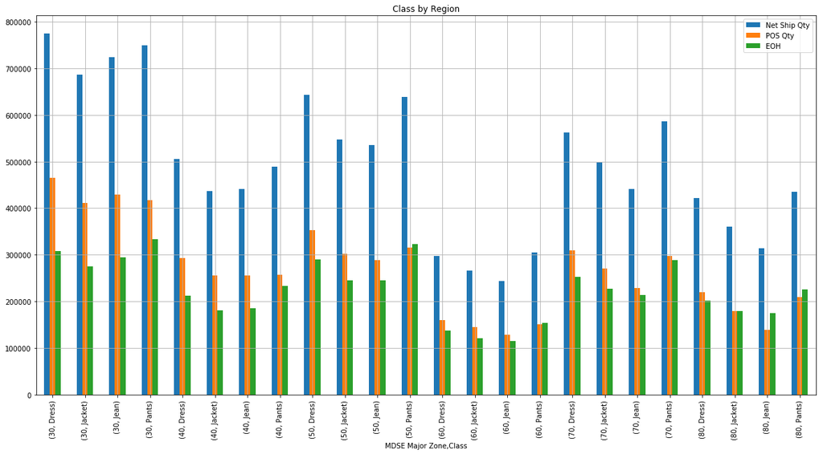

| Class MDSE Major Zone | POS Qty Dress | POS Qty Jacket | POS Qty Jean | POS Qty Pants |
| --- | --- | --- | --- | --- |
| 10 | 6825 | 9178 | 9697 | 7674 |
| 20 | 91236 | 78463 | 83497 | 89808 |
| 30 | 465612 | 411203 | 428992 | 416738 |
| 40 | 292902 | 255809 | 256112 | 256955 |
| 50 | 353432 | 301314 | 289256 | 314772 |
| 60 | 160574 | 144754 | 129034 | 151287 |
| 70 | 309173 | 270152 | 228018 | 296853 |
| 80 | 219681 | 179757 | 139293 | 209710 |
| 90 | 14225 | 10986 | 7818 | 13139 |

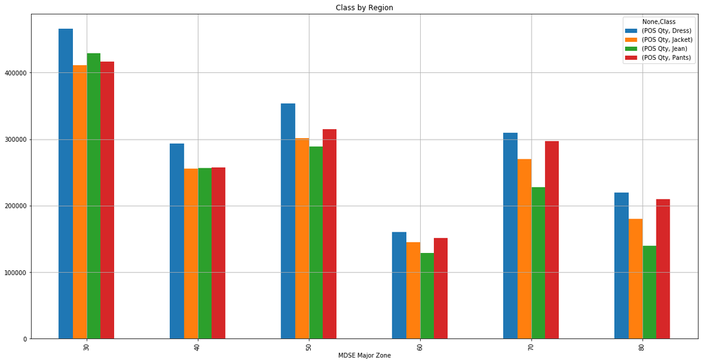

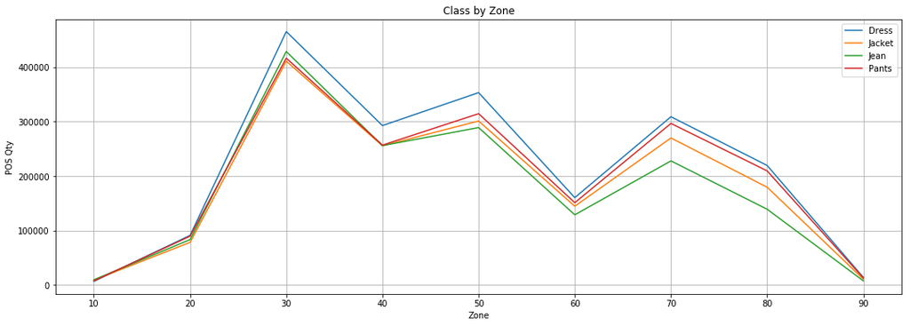

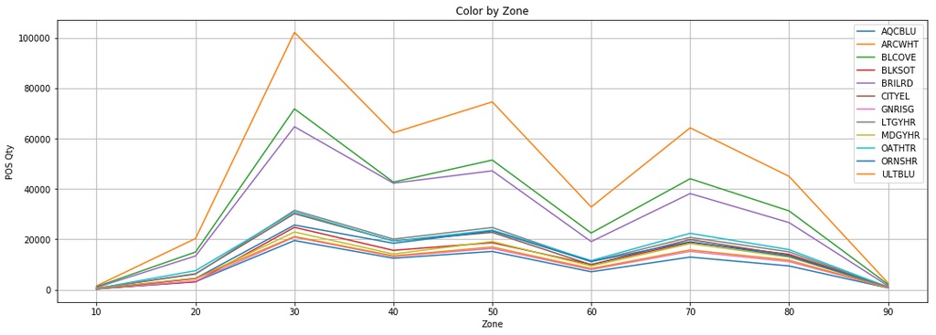

## Women's Department Missing opportunity & Zero Sales Issue

### One of the most common issues that retail companies have is item shortage. Such shortage could occur in colors, sizes, quantities shipped to stores, etc. By examining the dataset, this issue can be easily identified and be used to assist decision-making.

```
Total 3953 Stores have shortage by Size Level
Size Level
1    0.18
0    0.18
6    0.17
00   0.16
4    0.15
2    0.15
Name: Size Desc, dtype: float64
Class Level (across sizes) - Jacket 28%, Dress 22%, Jean 21%, Skirt 10%


Total 938 Stores have shortage by Color Level
Class Level (across sizes) - Jacket 32%, Dress 16%, Jean - 12%, Skirt - 9%
```

### Below table shows the number of stores that do not have the corresponding merchandises and thus missing sales opportunities. Inventory refers to the total quantity of items in stores that do have those merchandises allocated.

| Class | Color Desc | Size Desc | Number of Store | Inventory |
| --- | --- | --- | --- | --- |
| Active Wear | APLLO | 0 | 17 | 578,697.0 |
|  |  | 00 | 9 | 309,474.0 |
|  |  | 1 | 23 | 825,125.0 |
|  |  | 2 | 19 | 765,776.0 |
|  |  | 4 | 38 | 1,548,462.0 |
|  |  | 6 | 28 | 1,108,380.0 |
|  | ARCWHT | 0 | 11 | 518,375.0 |
|  |  | 00 | 17 | 781,694.0 |
|  |  | 1 | 12 | 605,280.0 |
|  |  | 2 | 16 | 913,120.0 |
|  |  | 4 | 17 | 1,058,488.0 |
|  |  | 6 | 7 | 410,060.0 |
|  | BLCOVE | 0 | 33 | 534,204.0 |
|  |  | 00 | 24 | 389,040.0 |
|  |  | 1 | 35 | 682,360.0 |
|  |  | 2 | 30 | 644,280.0 |
|  |  | 4 | 30 | 697,170.0 |
|  |  | 6 | 73 | 1,520,006.0 |
|  | GUMBAL | 0 | 16 | 657,664.0 |
|  |  | 00 | 21 | 843,843.0 |
|  |  | 1 | 19 | 794,295.0 |
|  |  | 2 | 33 | 1,575,651.0 |
|  |  | 4 | 37 | 1,888,406.0 |
|  |  | 6 | 22 | 1,047,728.0 |
|  | PCHSMT | 0 | 6 | 224,316.0 |
|  |  | 00 | 8 | 284,240.0 |
|  |  | 1 | 10 | 384,830.0 |
|  |  | 2 | 5 | 220,900.0 |
|  |  | 4 | 21 | 934,878.0 |
|  |  | 6 | 10 | 448,000.0 |
| ... | ... | ... | ... | ... |
| Top | BLKSOT | 0 | 74 | 1,437,894.0 |
|  |  | 00 | 65 | 1,259,635.0 |
|  |  | 1 | 38 | 1,025,696.0 |
|  |  | 2 | 15 | 485,655.0 |
|  |  | 4 | 12 | 408,732.0 |
|  |  | 6 | 16 | 507,296.0 |
|  | BRILRD | 0 | 39 | 695,565.0 |
|  |  | 00 | 49 | 797,524.0 |
|  |  | 1 | 12 | 247,092.0 |
|  |  | 2 | 10 | 265,710.0 |
|  |  | 4 | 10 | 273,130.0 |
|  |  | 6 | 7 | 176,421.0 |
|  | LTGYHR | 0 | 21 | 416,325.0 |
|  |  | 00 | 22 | 418,946.0 |
|  |  | 1 | 12 | 318,948.0 |
|  |  | 2 | 22 | 638,968.0 |
|  |  | 4 | 14 | 421,204.0 |
|  |  | 6 | 9 | 242,091.0 |
|  | MDGYHR | 0 | 35 | 667,275.0 |
|  |  | 00 | 30 | 554,850.0 |
|  |  | 1 | 13 | 335,933.0 |
|  |  | 2 | 10 | 298,660.0 |
|  |  | 4 | 15 | 476,220.0 |
|  |  | 6 | 9 | 255,645.0 |
|  | ULTBLU | 0 | 53 | 920,186.0 |
|  |  | 00 | 39 | 673,257.0 |
|  |  | 1 | 15 | 308,310.0 |
|  |  | 2 | 22 | 567,776.0 |
|  |  | 4 | 25 | 663,975.0 |
|  |  | 6 | 8 | 204,968.0 |

628 rows × 2 columns

| Class | Color Desc | Number of Store | Inventory |
| --- | --- | --- | --- |
| Active Wear | APLLO | 134 | 5,135,914.0 |
|  | ARCWHT | 80 | 4,287,017.0 |
|  | BLCOVE | 225 | 4,467,060.0 |
|  | GUMBAL | 148 | 6,807,587.0 |
|  | PCHSMT | 60 | 2,497,164.0 |
|  | REDRVR | 61 | 2,358,533.0 |
|  | SNPDYW | 250 | 7,277,425.0 |
| Coat | ARCWHT | 212 | 4,254,356.0 |
|  | BLCOVE | 89 | 3,754,788.0 |
|  | BLKSOT | 46 | 2,414,756.0 |
|  | BRILRD | 44 | 2,137,680.0 |
|  | CLDGRE | 1753 | 13,726,073.0 |
|  | GNRISG | 68 | 2,625,786.0 |
|  | MDGYHR | 581 | 10,083,067.0 |
|  | ORNSHR | 56 | 2,261,922.0 |
| Dress | AQCBLU | 8771 | 30,057,255.0 |
|  | ARCWHT | 57 | 1,961,292.0 |
|  | BLCOVE | 16 | 642,829.0 |
|  | BLKSOT | 5656 | 32,011,918.0 |
|  | BRILRD | 29 | 954,302.0 |
|  | CITYEL | 729 | 10,584,606.0 |
|  | GNRISG | 6485 | 34,927,861.0 |
|  | LTGYHR | 117 | 2,342,541.0 |
|  | MDGYHR | 1940 | 22,781,611.0 |
|  | OATHTR | 87 | 1,889,158.0 |
|  | ORNSHR | 3923 | 28,042,352.0 |
|  | ULTBLU | 49 | 1,331,390.0 |
| Jacket | AGVRDE | 500 | 14,644,978.0 |
|  | APLLO | 270 | 4,403,975.0 |
|  | ARCWHT | 65 | 1,419,493.0 |
| ... | ... | ... | ... |
| Short | LTGYHR | 629 | 8,742,150.0 |
|  | RNBOW | 3423 | 23,755,150.0 |
| Skirt | AQCBLU | 2070 | 20,156,804.0 |
|  | ARCWH2 | 534 | 5,185,843.0 |
|  | ARCWHT | 49 | 1,037,028.0 |
|  | BLCOVE | 97 | 1,759,184.0 |
|  | BLKSOT | 50 | 1,012,604.0 |
|  | BRILRD | 224 | 4,656,401.0 |
|  | CITYEL | 334 | 3,223,661.0 |
|  | GNRISG | 449 | 4,681,003.0 |
|  | LTBLHT | 342 | 3,230,800.0 |
|  | LTGYHR | 2561 | 18,648,749.0 |
|  | MDGYHR | 341 | 6,713,319.0 |
|  | ORNSHR | 5430 | 26,340,429.0 |
|  | ULTBLU | 179 | 1,746,677.0 |
| Sweater | AGVRDE | 495 | 14,296,623.0 |
|  | ARCWH2 | 1708 | 13,464,302.0 |
|  | ARCWHT | 358 | 8,875,805.0 |
|  | BAJBLU | 415 | 11,750,475.0 |
|  | BBLGPK | 691 | 13,214,491.0 |
|  | BLKSOT | 35 | 663,845.0 |
|  | GUMBAL | 120 | 2,552,767.0 |
|  | RNBOW | 3924 | 22,490,821.0 |
|  | SNPDYW | 372 | 4,043,173.0 |
| Top | BLCOVE | 391 | 8,819,220.0 |
|  | BLKSOT | 220 | 5,124,908.0 |
|  | BRILRD | 127 | 2,455,442.0 |
|  | LTGYHR | 100 | 2,456,482.0 |
|  | MDGYHR | 112 | 2,588,583.0 |
|  | ULTBLU | 162 | 3,338,472.0 |

105 rows × 2 columns